# Investigating and Analysing England Household Census Dataset 2021

# 1 Introduction

The data under study is derived from a complete household census conducted in England in 2021, and it includes a wide range of variables, from demographic traits to socioeconomic indicators. This investigation is motivated by a desire to gain insights into the complexities of family composition, providing light on patterns that shape the lives of individuals in the examined families.

To understand the distribution of each variable and the connections between them, we have generated visualizations during our initial analysis of the dataset(Giorgi, Ceraolo, and Mercatelli 2022). This visualization chart https://r-graph-gallery.com/ggplot2-package.html will help to understand meaningful insight from the data set.

# 2 The Data

The dataset we are examining is a modified data set collected during a household census conducted in England in 2021. It includes the following variables:

# 3 Summary

When it comes to explaining economic disparities, ethnicity takes center stage, with whites having greater median incomes than Asians and others. A line plot efficiently captures the gender distribution across age groups, establishing the framework for understanding gender dynamics at various life stages.

These visualizations give a complete view of the interaction between age, marital status, income, ethnicity, and gender in the questioned homes. The findings have implications for sociodemographic research, policy formation, and a better understanding of the many elements that influence household dynamics in England. The online resource https://r4ds.had.co.nz/ acts as a complete study guide for R programming and data science methodologies(Hadley Wickham 2023).

# 4 The Interesting Thing Discovered From This Dataset

We will generate some basic visualizations to better understand the distribution of the data. We’ll visualize a few data sets by creating histograms for the numerical variable (`Age`), and bar plots for the categorical variable (`Mar_Stat`). This visualization is carried out using (Wickham 2016), (Arnold 2021), and below the graphical view and findings.

## 4.1 Age and Marital Status Distribution

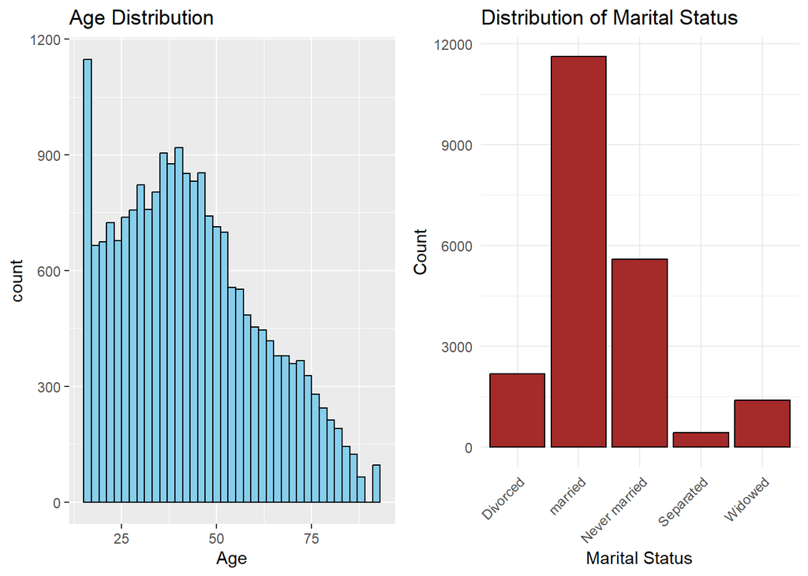

From these visualizations, we can observe the following:

*Age Distribution*: The histogram shows the age of individuals in the dataset is somewhat evenly distributed with a slight skew towards younger ages. It displays a visualization of the individuals who participated in this census, which means we can see that the age range of 25-50 adults is primarily assessed, while those over 75 are undercounted.

*Marital Status Distribution:* The bar chart shows The majority of individuals in the dataset have been married. Also, we use a grid setup(Wilke 2022) to keep the charts side by side.

We can also explore the relationships between these variables. We can do this by creating scatter plots for numerical variables and box plots and bar charts for categorical variables against numerical variables.

Specifically, we can look at:

- The relationship between Age and Income.
- The distribution of Income across different Marital Statuses.
- The distribution of Median Income across Ethnicities.
- The distribution of Gender Distribution Across Age  
  Let’s generate these plots.

## 4.2 Age vs Income with a linear regression line

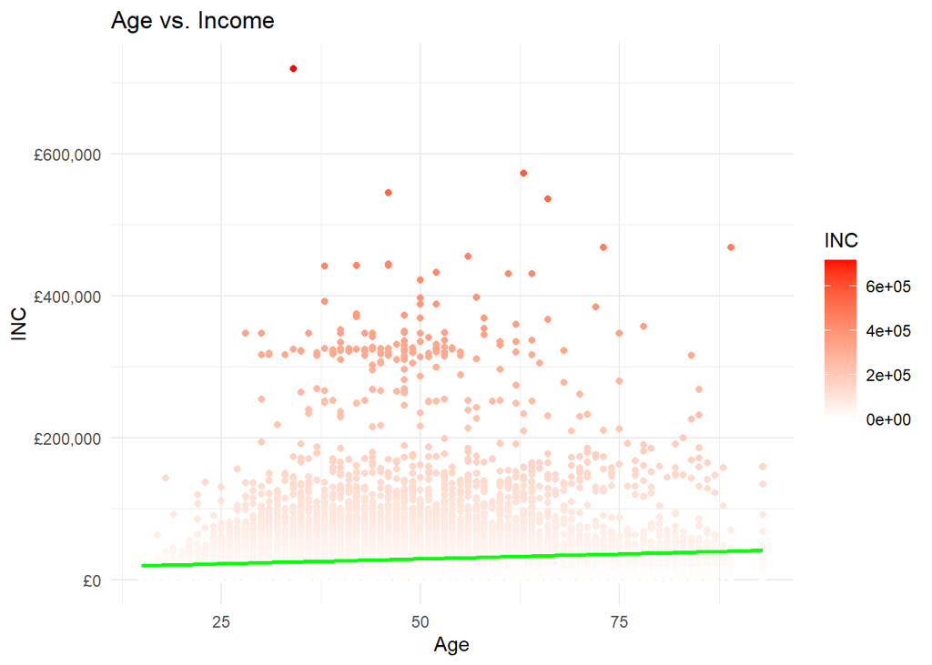

From this scatterplot(Nordmann et al. 2022) visualization the regression line shows a positive slope, indicating that, on average, as individuals’ age increases, their annual income tends to increase as well. This positive correlation suggests that older individuals, on average, may have higher incomes compared to their younger counterparts.

## 4.3 Income by Marital Status

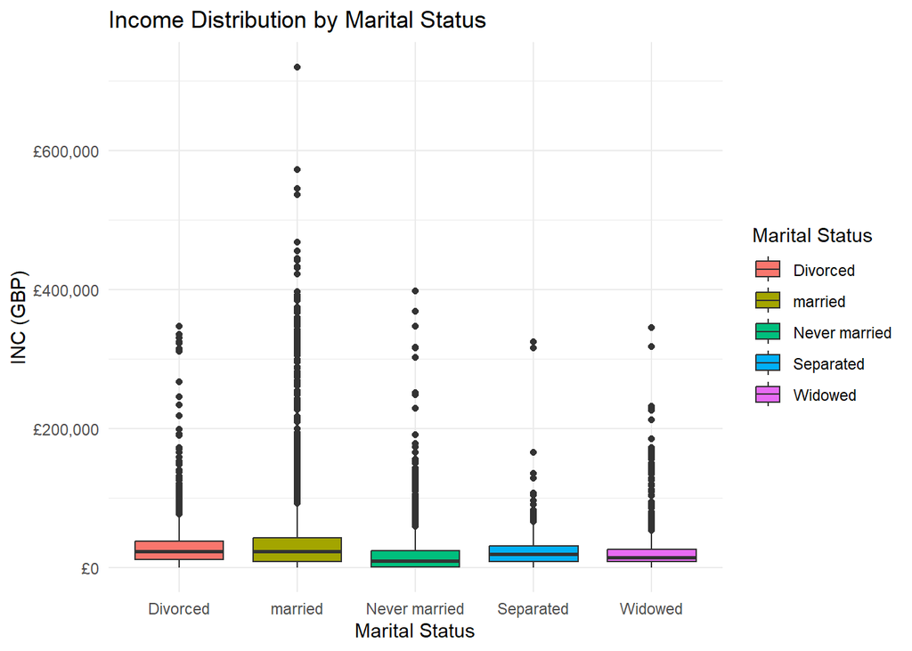

## 4.4 Median Income across Ethnicities

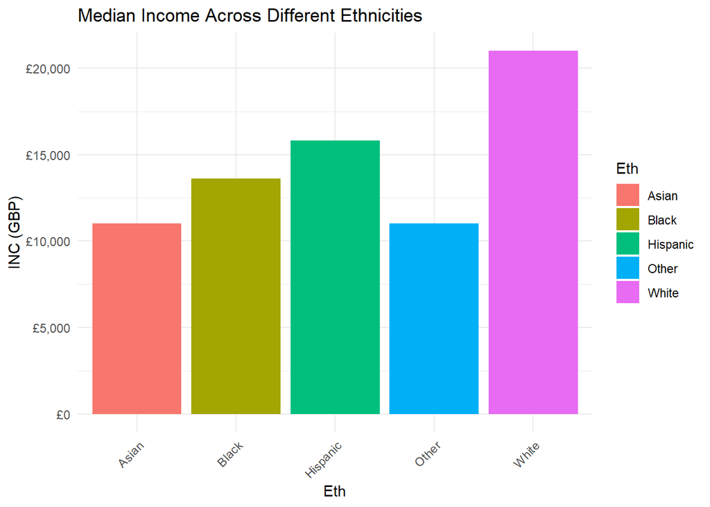

By comparing the heights of the bars, we can quickly identify ethnic groups with higher or lower median incomes. The visualization shows whites have higher income the range above £20,000. Also, we can understand that Asian and Other Ethnicity has a lower income range of £11,000.

## 4.5 Gender Distribution Across Age

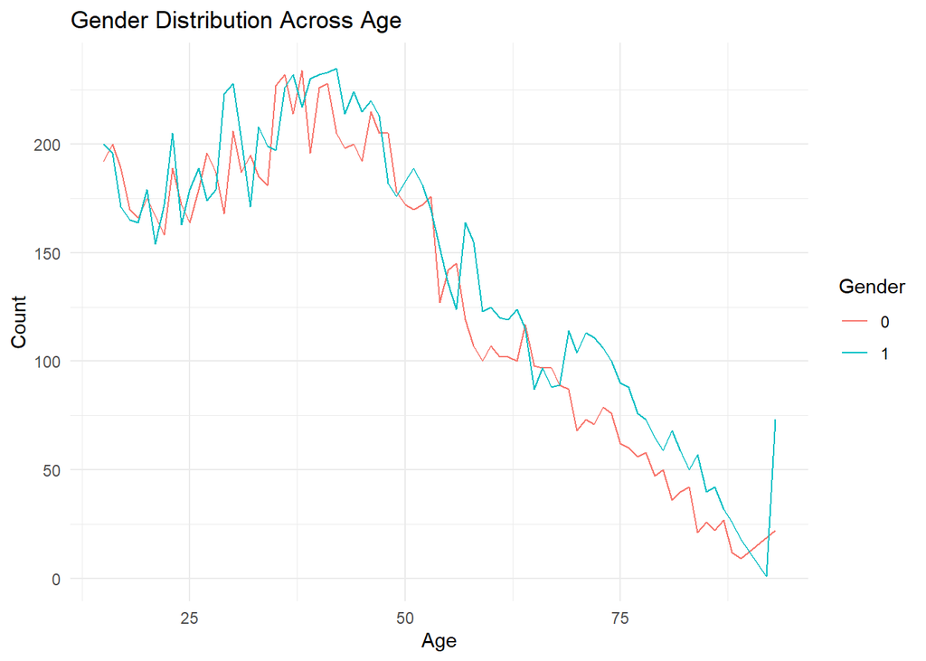

The line plot provides a visually appealing analysis of gender dynamics, laying the groundwork for further research into the factors influencing gender composition within different age groups. Many lines in the plot represent different genders. Each line represents the number of people of a particular gender at various ages.

# 5 Conclusion

In conclusion, the examination of the adjusted household census information yields significant insights into the complicated tapestry of demographic and socioeconomic elements that shape homes in England. The visualizations give insight into the distribution of age and marital status, revealing patterns that highlight the variety of the population question. The positive association between age and income suggests a complicated relationship that warrants additional examination.

Additionally, wage discrepancies between marital statuses underscore the economic ramifications of family arrangements, with married people earning more than single people. Ethnicity appears as a key predictor of income disparities, highlighting the importance of complex considerations in tackling socioeconomic inequities. The gender distribution across age groups demonstrates a dynamic interaction, laying the path for further research into the variables influencing gender dynamics at different phases of life.

These findings contribute to our understanding of society systems, laying the groundwork for focused study and informed decisions. The implications of the dataset go beyond simple statistical observations, suggesting a thorough investigation of the underlying causes impacting household dynamics. This research is a helpful resource for creating policies that address the various characteristics of age, marital status, income, race, and gender in England as we traverse the intricacies of social systems.

## References

Arnold, Jeffrey B. 2021. “Ggthemes: Extra Themes, Scales and Geoms for ’Ggplot2’.” https://CRAN.R-project.org/package=ggthemes.

Giorgi, Federico M., Carmine Ceraolo, and Daniele Mercatelli. 2022. “The R Language: An Engine for Bioinformatics and Data Science.” *Life* 12 (5): 648. https://doi.org/10.3390/life12050648.

Hadley Wickham, Garrett Grolemund, Mine Çetinkaya-Rundel. 2023. “R or Data Science.” https://r4ds.had.co.nz/.

Nordmann, Emily, Phil McAleer, Wilhelmiina Toivo, Helena Paterson, and Lisa M. DeBruine. 2022. “Data Visualization Using R for Researchers Who Do Not Use R.” *Advances in Methods and Practices in Psychological Science* 5 (2): 251524592210746. https://doi.org/10.1177/25152459221074654.

Wickham, Hadley. 2016. “Ggplot2: Elegant Graphics for Data Analysis.” https://ggplot2.tidyverse.org.

Wilke, Claus O. 2022. “Ggridges: Ridgeline Plots in ’Ggplot2’.” https://CRAN.R-project.org/package=ggridges.